# Case Study: Predict Mental Health for Young Americans using GSS Data

## Response Variable and ZINB

Our response variable, `menthlth`, is distributed in a peculiar shape, in that (i) there is a fat tail and (ii) about half of the response are zeros. The ordinary models for count data, such as Poisson regression and binomial regression, are therefore no more suitable. To address the overdispersion and the excess of zeros, we decide to model `menthlth` with the **zero-inflated negative binomial (ZINB)** regression.

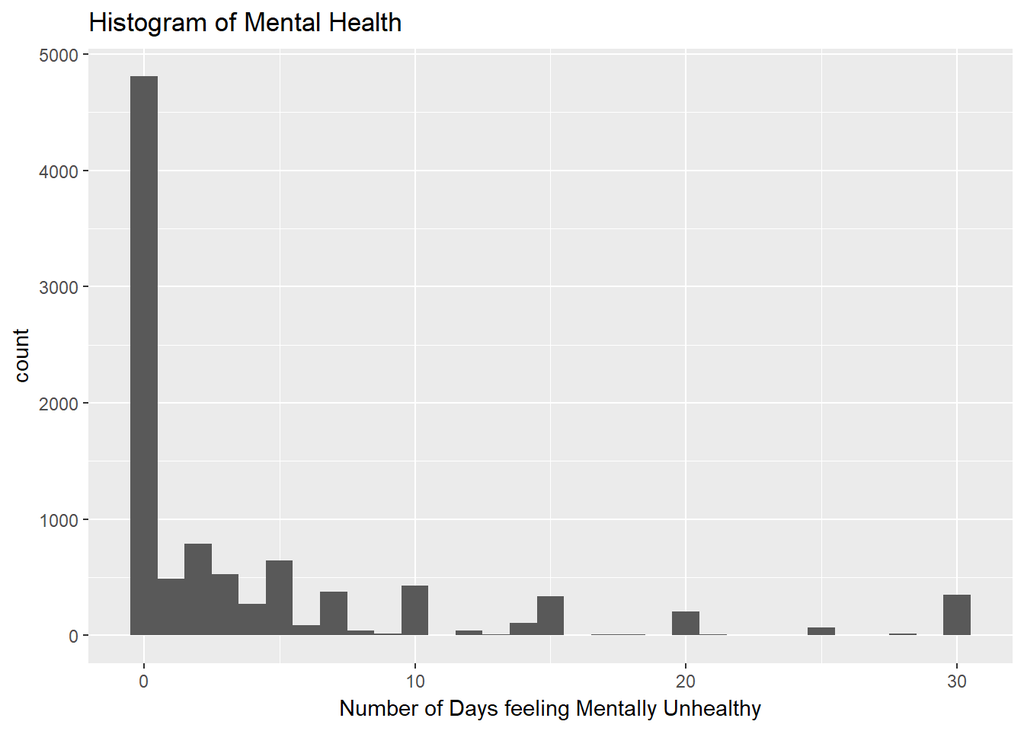

```r
# plot the histogram of the number of days feeling mentally unhealthy
ggplot(data=DATA, aes(x=menthlth)) +
  geom_histogram(binwidth=1) +
  xlab("Number of Days feeling Mentally Unhealthy") +
  ggtitle("Histogram of Mental Health")
```

```r
# compute the proportion of respondents who don't feel mentally unhealthy at all
prop <- nrow(DATA %>% filter(menthlth==0)) / N
prop <- round(prop, digits=4)
cat(100*prop,"% of the responses are zeros.")
```

```
## 49.71 % of the responses are zeros.
```

In ZINB, the zero responses are not only contributed by the count process but also a binary process. The latter indicates whether or not an individual is genetically susceptible to mental illness and/or under detrimental circumstances, which we plan to predict by the logistic regression with long-term to permanent factors, such as gender, income, race, and so on. The former only applies when the latter “succeeds” and communicates how many mentally unhealthy days that the intrinsic or extrinsic adversity would elicit in a month, which we intend to predict by the negative binomial regression majorly with short-term to mid-term factors, such as diet, BMI, exercises, and so on.

Suppose the $j^{th}$ respondent is exposed to triggering circumstances with probability $\pi_j$ and feels mentally unhealthy in $Y_j$ days during the past month, then
$$\begin{cases}
P(W_j=1)=\pi_j
\\
P(W_j=0) = 1 - \pi_j \\
\end{cases}$$
where $W_j$ is the binary indicator of exposure, and
$$\begin{align*}
P(Y_j=0) &= P(W_j=0) \times P(Y_j=0|W_j=0) + P(W_j=1) \times P(Y_j=0|W_j=1) \\
&= (1-\pi_j) \times 1 \; + \; \pi_j \times p_j^{r_j}
\end{align*}$$
$$\begin{align*}
P(Y_j=k)&=P(W_j=0) \times P(Y_j=k|W_j=0) + P(W_j=1) \times P(Y_j=k|W_j=1) \\
&= 0 + \pi_j \cdot P(Y_j=k|W_j=1) \\
&= \pi_j \cdot \binom{k+r_j-1}{r_j-1}p_j^{r_j}(1-p_j)^k
\end{align*}$$
in which $k>0$ and $Y_j|W_j=1$ follows the negative binomial distribution $NB(r_j,p_j)$.

In short, there are three parameters that link the response to the predictors, namely, $\pi$, $r$, and $p$. Note that the interpretation of $r$ and $p$ is not straightforward. But if we assume that $r$ independent steps are required to conquer the psychological difficulties and one is equally likely to succeed in each attempt at each step, the negative binomial model is not outrageously unreasonable.

## Exploratory Data Analysis

The purpose of exploratory data analysis (EDA) is a rough idea of the dependency of the response upon each predictor and the interrelationship among predictors, so that the pool of candidates might be reduced to more managable size.

### Numerical Predictors

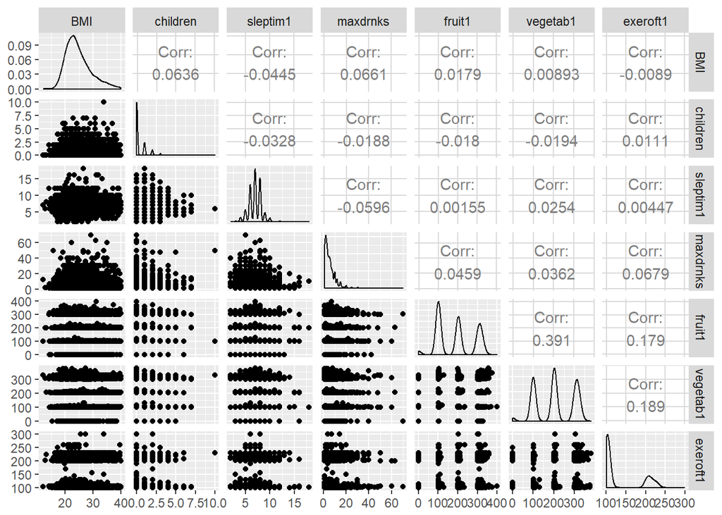

```r
# Explore the distributions of and correlations between numerical variables
ggpairs(DATA, columns=c(10:12,14:17))
```

Other than the plausible correlation between `fruit1` and `vegetab1`, and the possible correlations between `exeroft1` and them, no colinearity among these numerical explanatory variables are found. We thereby construct by **principal component analysis (PCA)** a new variable, `DIET`, to extract $70\%$ of the variances from `fruit1` and `vegetab1`.

```r
# project two variables onto a one-dimensional subspace
diet.pca <- prcomp(DATA[,15:16], center = TRUE,scale. = TRUE)
# add the projection to the dataset
DATA <- DATA %>%
  mutate(DIET = diet.pca$x[,1])
# check how much variance the projection can explain
summary(diet.pca)
```

```
## Importance of components:
##                           PC1    PC2
## Standard deviation     1.1794 0.7804
## Proportion of Variance 0.6955 0.3045
## Cumulative Proportion  0.6955 1.0000
```

It becomes meaningless to compute the correlations between `menthlth` and each predictor as their relationships in ZINB regression are not presumed to be linear any more. Besides, scatterplots hardly display any patterns, regardless of continuous or discrete predictors. This might be resulted by the discreteness and the extreme skewedness of `menthlth`.

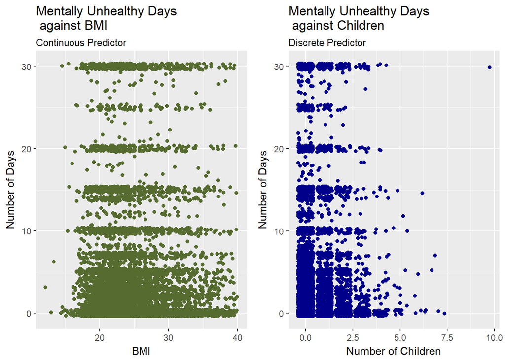

```r
# plot menthlth against BMI
g1 <- ggplot(DATA, aes(x=BMI,y=menthlth)) +
        geom_jitter(color="darkolivegreen") +
        ylab("Number of Days") +
        ggtitle(label=paste("Mentally Unhealthy Days \n against BMI"),
                subtitle="Continuous Predictor")
# plot menthlth against children
g2 <- ggplot(DATA, aes(x=children,y=menthlth)) +
        geom_jitter(color="darkblue") +
        ylab("Number of Days") +
        xlab("Number of Children") +
        ggtitle(label=paste("Mentally Unhealthy Days \n against Children"),
                subtitle="Discrete Predictor")
grid.arrange(g1,g2,nrow=1)
```

### Categorical Predictors

Two of the pairwise segmented barplots among categorical predictors suggest statistical dependency between `Class` and `smoke100`, and between `GENDER` and `X_educag`. In specific, the higher the socio-economic class, the fewer people smoke during the past $100$ days. And a larger proportion of females have at least obtained some post-secondary education than males have. Given the sample size, $N=9673$, the differences are rather considerable.

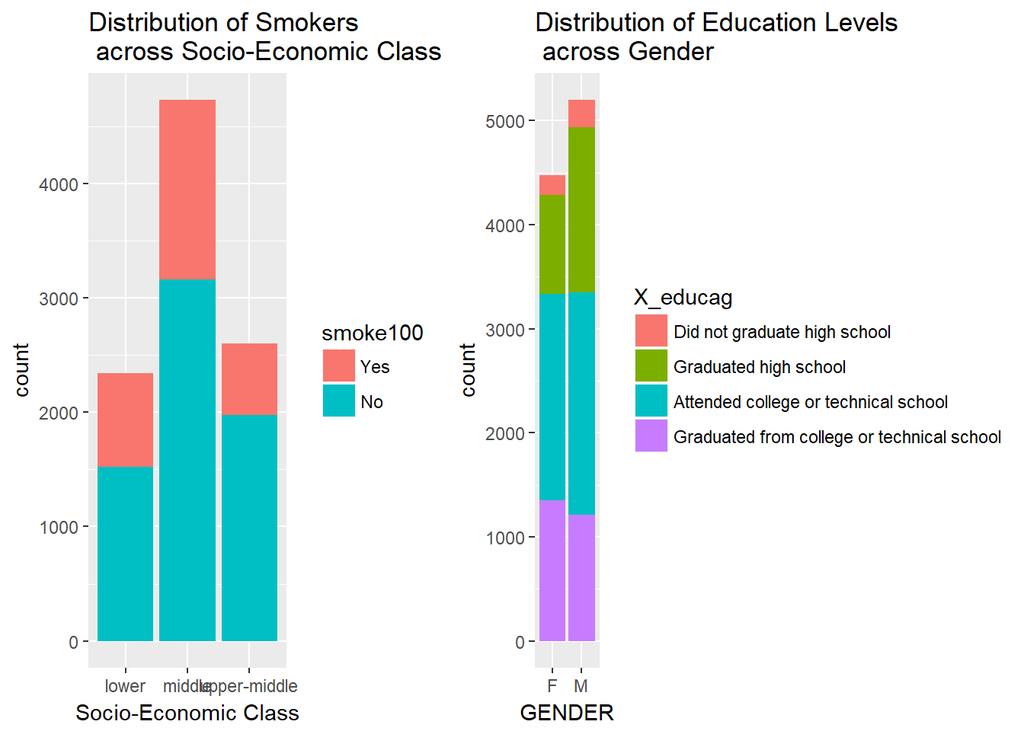

```r
# plot smoke100 against socioeconomic class
g3 <- ggplot(DATA, aes(x=Class,fill=smoke100)) +
        geom_bar() +
        xlab("Socio-Economic Class") +
        ggtitle("Distribution of Smokers \n across Socio-Economic Class")
# plot education against gender
g4 <- ggplot(DATA, aes(x=GENDER,fill=X_educag)) +
        geom_bar() +
        ggtitle("Distribution of Education Levels \n across Gender")
grid.arrange(grobs=list(g3,g4), widths=c(1.7,2.2), layout_matrix=matrix(c(1,2),nrow=1,ncol=2))
```

That said, we decide to retain all of these four predictors and be wary. This is to avoid premature information loss as they describe an individual from distinct perspectives. We do expect at least one to be insignificant when a pair are regressed upon.

Furthermore, `DISRICT` and `X_race` are excluded from the candidates as `menthlth` only fluctuates negligibly across their levels compared to the intrinsic volatility.

```r
# summarize the average and standard deviation
# across levels of DISTRICT
DATA %>%
  group_by(DISTRICT) %>%
  summarise(count=n(), avg_mental=mean(menthlth), sd_mental=sd(menthlth))
```

```
## # A tibble: 7 x 4
##   DISTRICT count avg_mental sd_mental
##   <chr>    <int>      <dbl>     <dbl>
## 1 Lakes     1661       4.17      6.97
## 2 Midwest   2803       3.91      6.95
## 3 New Eng   1017       4.56      7.20
## 4 Others     185       3.78      7.81
## 5 Pacific   1112       4.26      7.24
## 6 South     1819       4.42      7.58
## 7 West      1076       4.66      7.60
```

```r
# summarize the average and standard deviation
# across levels of race
DATA %>%
  group_by(X_race) %>%
  summarise(count=n(), avg_mental=mean(menthlth), sd_mental=sd(menthlth))
```

```
## # A tibble: 8 x 4
##   X_race                                             count avg_mental sd_mental
##   <fct>                                              <int>      <dbl>     <dbl>
## 1 White only, non-Hispanic                            6950       4.13      7.04
## 2 Black only, non-Hispanic                             624       4.51      7.90
## 3 American Indian or Alaskan Native only, Non-Hispa~   152       5.60      8.74
## 4 Asian only, non-Hispanic                             305       3.24      6.03
## 5 Native Hawaiian or other Pacific Islander only, N~    72       4.53      8.41
## 6 Other race only, non-Hispanic                         58       6.71      9.63
## 7 Multiracial, non-Hispanic                            363       5.45      8.26
## 8 Hispanic                                            1149       4.29      7.38
```

### Numerical VS Categorical

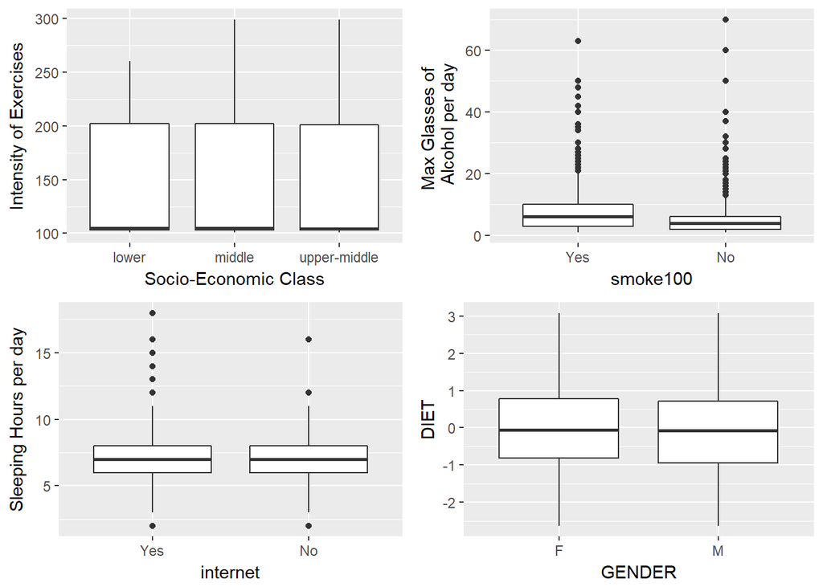

```r
g5 <- ggplot(DATA, aes(x=Class, y=exeroft1)) +
  geom_boxplot() +
  xlab("Socio-Economic Class") +
  ylab("Intensity of Exercises")

g6 <- ggplot(DATA, aes(x=internet, y=sleptim1)) +
  geom_boxplot() +
  ylab("Sleeping Hours per day")

g7 <- ggplot(DATA, aes(x=smoke100, y=maxdrnks)) +
  geom_boxplot() +
  ylab("Max Glasses of \n Alcohol per day")

g8 <- ggplot(DATA, aes(x=GENDER, y=DIET)) +
  geom_boxplot()

grid.arrange(grobs=list(g5,g6,g7,g8), widths=c(1,1), layout_matrix=matrix(1:4,nrow=2,ncol=2))
```

As a result, we manage to prune the candidates to be six numerical and seven categorical variables.

| NUMERICAL | Description |
| --- | --- |
| `BMI` | The body mass index that reflects the relationship between height and weight |
| `children` | The number of children one has |
| `sleptim1` | The average number of hours one sleeps per day during the past month |
| `maxdrnks` | The maximum number of glasses of alcohol one drinks per day during the past month |
| `DIET` | The index constructed by PCA from `fruit1` and `vegetab1` |
| `exeroft1` | The average intensity of exercises during the past month |

| CATEGORICAL | Description |
| --- | --- |
| `GENDER` | The biological gender |
| `X_educag` | The highest education level ones has completed |
| `Class` | The Socio-Economic Class determined by annual family income |
| `cellphone` | Whether one owns a personal cellphone |
| `internet` | Whether one accesses the internet during the past month |
| `medcost` | Whether one has unpaid medical bills |
| `smoke100` | Whether one smokes during the past 100 days |

## Backward Model Selection

We start with the full model and drop the most insignificant predictor, if any, until every p-value is sufficiently small. As psychologists recommend, the full model will include the **interaction** between `GENDER` and `children`, `GENDER` and `sleptim1`, `GENDER` and `smoke100`, and `BMI` and `maxdrnks`.

Again, the central idea is to use long-term to permanent factors for the binary process and short-term to mid-term factors for the count process in **ZINB regression**.

```r
# randomly pick one subset for testing
# select model with the rest of observations
set.seed(999)
j <- sample(1:k, 1)
TRAIN <- DATA[setdiff(1:N,ID[[j]]),]
# train the full model
m1 <- zeroinfl(menthlth ~ GENDER + children + BMI + sleptim1 + maxdrnks + DIET + exeroft1 +
                 GENDER:children + GENDER:sleptim1 + BMI:maxdrnks
               | GENDER + X_educag + Class + cellphone + internet + medcost + smoke100 + BMI +
                 GENDER:smoke100,
               data = TRAIN, dist = "negbin", EM = TRUE)
summary(m1)
```

```
##
## Call:
## zeroinfl(formula = menthlth ~ GENDER + children + BMI + sleptim1 + maxdrnks +
##     DIET + exeroft1 + GENDER:children + GENDER:sleptim1 + BMI:maxdrnks |
##     GENDER + X_educag + Class + cellphone + internet + medcost + smoke100 +
##         BMI + GENDER:smoke100, data = TRAIN, dist = "negbin", EM = TRUE)
##
## Pearson residuals:
##     Min      1Q  Median      3Q     Max
## -0.8012 -0.5521 -0.4693  0.1317  9.6019
##
## Count model coefficients (negbin with log link):
##                    Estimate Std. Error z value Pr(>|z|)
## (Intercept)       1.9161208  0.1825880  10.494  < 2e-16 ***
## GENDERM          -0.0296226  0.1651006  -0.179 0.857607
## children          0.0643921  0.0294840   2.184 0.028964 *
## BMI               0.0159308  0.0051086   3.118 0.001818 **
## sleptim1         -0.0840437  0.0159713  -5.262 1.42e-07 ***
## maxdrnks          0.0672903  0.0165125   4.075 4.60e-05 ***
## DIET             -0.0172969  0.0151980  -1.138 0.255078
## exeroft1          0.0014303  0.0003682   3.885 0.000102 ***
## GENDERM:children -0.0053208  0.0434346  -0.123 0.902503
## GENDERM:sleptim1 -0.0353985  0.0229001  -1.546 0.122158
## BMI:maxdrnks     -0.0019054  0.0005836  -3.265 0.001094 **
## Log(theta)       -0.1905160  0.0450034  -4.233 2.30e-05 ***
##
## Zero-inflation model coefficients (binomial with logit link):
##                                                     Estimate Std. Error z value
## (Intercept)                                        -2.691338   0.285612  -9.423
## GENDERM                                             0.790621   0.126842   6.233
## X_educagGraduated high school                      -0.044587   0.153003  -0.291
## X_educagAttended college or technical school       -0.112207   0.150956  -0.743
## X_educagGraduated from college or technical school -0.175003   0.156876  -1.116
## Classmiddle                                         0.263860   0.077345   3.411
## Classupper-middle                                   0.233459   0.086918   2.686
## cellphoneYes                                        0.072805   0.072245   1.008
## internetNo                                          0.607087   0.181786   3.340
## medcostNo                                           0.984964   0.113206   8.701
## smoke100No                                          0.477334   0.119349   3.999
## BMI                                                 0.021939   0.006822   3.216
## GENDERM:smoke100No                                 -0.178912   0.142890  -1.252
##                                                    Pr(>|z|)
## (Intercept)                                         < 2e-16 ***
## GENDERM                                            4.57e-10 ***
## X_educagGraduated high school                      0.770737
## X_educagAttended college or technical school       0.457293
## X_educagGraduated from college or technical school 0.264617
## Classmiddle                                        0.000646 ***
## Classupper-middle                                  0.007232 **
## cellphoneYes                                       0.313572
## internetNo                                         0.000839 ***
## medcostNo                                           < 2e-16 ***
## smoke100No                                         6.35e-05 ***
## BMI                                                0.001300 **
## GENDERM:smoke100No                                 0.210534
## ---
## Signif. codes:  0 '***' 0.001 '**' 0.01 '*' 0.05 '.' 0.1 ' ' 1
##
## Theta = 0.8265
## Number of iterations in BFGS optimization: 1
## Log-likelihood: -1.705e+04 on 25 Df
```

Not to our surprise, `X_educag` is among the insignificant predictors whereas `GENDER` is extraordinarily significant. Dropping the interaction between `GENDER` and `children` since it is associated with the largest insignificant p-value, we then pass on the rest of candidates to the next step.

```r
m2 <- zeroinfl(menthlth ~ GENDER + children + BMI + sleptim1 + maxdrnks + DIET + exeroft1 +
                 GENDER:sleptim1 + BMI:maxdrnks
               | GENDER + X_educag + Class + cellphone + internet + medcost + smoke100 + BMI +
                 GENDER:smoke100,
               data = TRAIN, dist = "negbin", EM = TRUE)
summary(m2)
```

```
##
## Call:
## zeroinfl(formula = menthlth ~ GENDER + children + BMI + sleptim1 + maxdrnks +
##     DIET + exeroft1 + GENDER:sleptim1 + BMI:maxdrnks | GENDER + X_educag +
##     Class + cellphone + internet + medcost + smoke100 + BMI + GENDER:smoke100,
##     data = TRAIN, dist = "negbin", EM = TRUE)
##
## Pearson residuals:
##     Min      1Q  Median      3Q     Max
## -0.8010 -0.5521 -0.4692  0.1326  9.5611
##
## Count model coefficients (negbin with log link):
##                    Estimate Std. Error z value Pr(>|z|)
## (Intercept)       1.9167364  0.1825829  10.498  < 2e-16 ***
## GENDERM          -0.0324933  0.1634368  -0.199 0.842409
## children          0.0619331  0.0216565   2.860 0.004239 **
## BMI               0.0159883  0.0050796   3.148 0.001646 **
## sleptim1         -0.0841646  0.0159398  -5.280 1.29e-07 ***
## maxdrnks          0.0674266  0.0164495   4.099 4.15e-05 ***
## DIET             -0.0173619  0.0151891  -1.143 0.253019
## exeroft1          0.0014303  0.0003682   3.885 0.000102 ***
## GENDERM:sleptim1 -0.0353147  0.0228919  -1.543 0.122910
## BMI:maxdrnks     -0.0019115  0.0005806  -3.292 0.000994 ***
## Log(theta)       -0.1906746  0.0449806  -4.239 2.24e-05 ***
##
## Zero-inflation model coefficients (binomial with logit link):
##                                                     Estimate Std. Error z value
## (Intercept)                                        -2.692265   0.285558  -9.428
## GENDERM                                             0.791099   0.126820   6.238
## X_educagGraduated high school                      -0.044676   0.153012  -0.292
## X_educagAttended college or technical school       -0.112307   0.150965  -0.744
## X_educagGraduated from college or technical school -0.175068   0.156887  -1.116
## Classmiddle                                         0.263962   0.077351   3.413
## Classupper-middle                                   0.233587   0.086921   2.687
## cellphoneYes                                        0.072869   0.072250   1.009
## internetNo                                          0.607022   0.181805   3.339
## medcostNo                                           0.985057   0.113223   8.700
## smoke100No                                          0.477755   0.119342   4.003
## BMI                                                 0.021949   0.006822   3.218
## GENDERM:smoke100No                                 -0.179422   0.142864  -1.256
##                                                    Pr(>|z|)
## (Intercept)                                         < 2e-16 ***
## GENDERM                                            4.43e-10 ***
## X_educagGraduated high school                      0.770305
## X_educagAttended college or technical school       0.456921
## X_educagGraduated from college or technical school 0.264470
## Classmiddle                                        0.000644 ***
## Classupper-middle                                  0.007202 **
## cellphoneYes                                       0.313187
## internetNo                                         0.000841 ***
## medcostNo                                           < 2e-16 ***
## smoke100No                                         6.25e-05 ***
## BMI                                                0.001292 **
## GENDERM:smoke100No                                 0.209153
## ---
## Signif. codes:  0 '***' 0.001 '**' 0.01 '*' 0.05 '.' 0.1 ' ' 1
##
## Theta = 0.8264
## Number of iterations in BFGS optimization: 1
## Log-likelihood: -1.705e+04 on 24 Df
```

By similar argument, we discard `GENDER` in the negative binomial regression and proceed. Note that the interaction between `GENDER` and `sleptim1` would be pointless without `GENDER`, so `GENDER:sleptim1` is also deleted.

```r
m3 <- zeroinfl(menthlth ~ children + BMI + sleptim1 + maxdrnks + DIET + exeroft1 +
                 BMI:maxdrnks
               | GENDER + X_educag + Class + cellphone + internet + medcost + smoke100 + BMI +
                 GENDER:smoke100,
               data = TRAIN, dist = "negbin", EM = TRUE)
summary(m3)
```

```
##
## Call:
## zeroinfl(formula = menthlth ~ children + BMI + sleptim1 + maxdrnks +
##     DIET + exeroft1 + BMI:maxdrnks | GENDER + X_educag + Class + cellphone +
##     internet + medcost + smoke100 + BMI + GENDER:smoke100, data = TRAIN,
##     dist = "negbin", EM = TRUE)
##
## Pearson residuals:
##     Min      1Q  Median      3Q     Max
## -0.7951 -0.5450 -0.4593  0.1301  7.0402
##
## Count model coefficients (negbin with log link):
##                Estimate Std. Error z value Pr(>|z|)
## (Intercept)   1.9892093  0.1659313  11.988  < 2e-16 ***
## children      0.0686299  0.0218555   3.140 0.001689 **
## BMI           0.0139650  0.0050954   2.741 0.006131 **
## sleptim1     -0.0985713  0.0115435  -8.539  < 2e-16 ***
## maxdrnks      0.0550472  0.0164679   3.343 0.000830 ***
## DIET         -0.0114259  0.0153103  -0.746 0.455495
## exeroft1      0.0013203  0.0003718   3.552 0.000383 ***
## BMI:maxdrnks -0.0016838  0.0005828  -2.889 0.003863 **
## Log(theta)   -0.2214901  0.0453801  -4.881 1.06e-06 ***
##
## Zero-inflation model coefficients (binomial with logit link):
##                                                     Estimate Std. Error z value
## (Intercept)                                        -2.825145   0.295297  -9.567
## GENDERM                                             0.918551   0.133703   6.870
## X_educagGraduated high school                      -0.057179   0.153933  -0.371
## X_educagAttended college or technical school       -0.126494   0.151984  -0.832
## X_educagGraduated from college or technical school -0.193654   0.158046  -1.225
## Classmiddle                                         0.268408   0.078418   3.423
## Classupper-middle                                   0.237942   0.087890   2.707
## cellphoneYes                                        0.074288   0.073006   1.018
## internetNo                                          0.605529   0.184157   3.288
## medcostNo                                           1.019653   0.117057   8.711
## smoke100No                                          0.508039   0.127702   3.978
## BMI                                                 0.022428   0.006917   3.243
## GENDERM:smoke100No                                 -0.205788   0.149265  -1.379
##                                                    Pr(>|z|)
## (Intercept)                                         < 2e-16 ***
## GENDERM                                            6.42e-12 ***
## X_educagGraduated high school                       0.71030
## X_educagAttended college or technical school        0.40525
## X_educagGraduated from college or technical school  0.22046
## Classmiddle                                         0.00062 ***
## Classupper-middle                                   0.00678 **
## cellphoneYes                                        0.30889
## internetNo                                          0.00101 **
## medcostNo                                           < 2e-16 ***
## smoke100No                                         6.94e-05 ***
## BMI                                                 0.00118 **
## GENDERM:smoke100No                                  0.16799
## ---
## Signif. codes:  0 '***' 0.001 '**' 0.01 '*' 0.05 '.' 0.1 ' ' 1
##
## Theta = 0.8013
## Number of iterations in BFGS optimization: 1
## Log-likelihood: -1.708e+04 on 22 Df
```

`DIET` ought to be excluded at this step. Even though one level of `X_educag` gives larger p-value, we want to be safe and only look at the smallest p-value associated with a factor.

```r
m4 <- zeroinfl(menthlth ~ children + BMI + sleptim1 + maxdrnks + exeroft1 + BMI:maxdrnks
               | GENDER + X_educag + Class + cellphone + internet + medcost + smoke100 + BMI +
                 GENDER:smoke100,
               data = TRAIN, dist = "negbin", EM = TRUE)
summary(m4)
```

```
##
## Call:
## zeroinfl(formula = menthlth ~ children + BMI + sleptim1 + maxdrnks +
##     exeroft1 + BMI:maxdrnks | GENDER + X_educag + Class + cellphone +
##     internet + medcost + smoke100 + BMI + GENDER:smoke100, data = TRAIN,
##     dist = "negbin", EM = TRUE)
##
## Pearson residuals:
##     Min      1Q  Median      3Q     Max
## -0.7950 -0.5451 -0.4595  0.1318  6.9920
##
## Count model coefficients (negbin with log link):
##                Estimate Std. Error z value Pr(>|z|)
## (Intercept)   1.9781192  0.1651771  11.976  < 2e-16 ***
## children      0.0683209  0.0218437   3.128 0.001762 **
## BMI           0.0140685  0.0050907   2.764 0.005717 **
## sleptim1     -0.0983472  0.0115332  -8.527  < 2e-16 ***
## maxdrnks      0.0549448  0.0164659   3.337 0.000847 ***
## exeroft1      0.0013791  0.0003633   3.796 0.000147 ***
## BMI:maxdrnks -0.0016794  0.0005827  -2.882 0.003951 **
## Log(theta)   -0.2202226  0.0452911  -4.862 1.16e-06 ***
##
## Zero-inflation model coefficients (binomial with logit link):
##                                                    Estimate Std. Error z value
## (Intercept)                                        -2.82350    0.29493  -9.573
## GENDERM                                             0.91759    0.13352   6.872
## X_educagGraduated high school                      -0.05654    0.15386  -0.367
## X_educagAttended college or technical school       -0.12574    0.15191  -0.828
## X_educagGraduated from college or technical school -0.19306    0.15797  -1.222
## Classmiddle                                         0.26863    0.07836   3.428
## Classupper-middle                                   0.23818    0.08782   2.712
## cellphoneYes                                        0.07394    0.07294   1.014
## internetNo                                          0.60567    0.18405   3.291
## medcostNo                                           1.01910    0.11689   8.719
## smoke100No                                          0.50870    0.12753   3.989
## BMI                                                 0.02243    0.00691   3.246
## GENDERM:smoke100No                                 -0.20655    0.14910  -1.385
##                                                    Pr(>|z|)
## (Intercept)                                         < 2e-16 ***
## GENDERM                                            6.32e-12 ***
## X_educagGraduated high school                      0.713291
## X_educagAttended college or technical school       0.407814
## X_educagGraduated from college or technical school 0.221648
## Classmiddle                                        0.000607 ***
## Classupper-middle                                  0.006686 **
## cellphoneYes                                       0.310691
## internetNo                                         0.000999 ***
## medcostNo                                           < 2e-16 ***
## smoke100No                                         6.64e-05 ***
## BMI                                                0.001171 **
## GENDERM:smoke100No                                 0.165943
## ---
## Signif. codes:  0 '***' 0.001 '**' 0.01 '*' 0.05 '.' 0.1 ' ' 1
##
## Theta = 0.8023
## Number of iterations in BFGS optimization: 1
## Log-likelihood: -1.708e+04 on 21 Df
```

All p-values associated with the negative binomial regression component have become sufficiently small. Now we eliminate `cellphone` for the logistic regression and continue the backward selection.

```r
m5 <- zeroinfl(menthlth ~ children + BMI + sleptim1 + maxdrnks + exeroft1 + BMI:maxdrnks
               | GENDER + X_educag + Class + internet + medcost + smoke100 + BMI +
                 GENDER:smoke100,
               data = TRAIN, dist = "negbin", EM = TRUE)
summary(m5)
```

```
##
## Call:
## zeroinfl(formula = menthlth ~ children + BMI + sleptim1 + maxdrnks +
##     exeroft1 + BMI:maxdrnks | GENDER + X_educag + Class + internet +
##     medcost + smoke100 + BMI + GENDER:smoke100, data = TRAIN, dist = "negbin",
##     EM = TRUE)
##
## Pearson residuals:
##     Min      1Q  Median      3Q     Max
## -0.7956 -0.5455 -0.4599  0.1317  7.0660
##
## Count model coefficients (negbin with log link):
##                Estimate Std. Error z value Pr(>|z|)
## (Intercept)   1.9778637  0.1651520  11.976  < 2e-16 ***
## children      0.0689095  0.0218400   3.155 0.001604 **
## BMI           0.0140486  0.0050898   2.760 0.005777 **
## sleptim1     -0.0982219  0.0115307  -8.518  < 2e-16 ***
## maxdrnks      0.0548693  0.0164641   3.333 0.000860 ***
## exeroft1      0.0013792  0.0003632   3.797 0.000147 ***
## BMI:maxdrnks -0.0016774  0.0005827  -2.879 0.003993 **
## Log(theta)   -0.2195366  0.0452452  -4.852 1.22e-06 ***
##
## Zero-inflation model coefficients (binomial with logit link):
##                                                     Estimate Std. Error z value
## (Intercept)                                        -2.756598   0.286142  -9.634
## GENDERM                                             0.918357   0.133295   6.890
## X_educagGraduated high school                      -0.051904   0.153557  -0.338
## X_educagAttended college or technical school       -0.118916   0.151525  -0.785
## X_educagGraduated from college or technical school -0.184150   0.157506  -1.169
## Classmiddle                                         0.263586   0.078120   3.374
## Classupper-middle                                   0.226512   0.087009   2.603
## internetNo                                          0.608491   0.183927   3.308
## medcostNo                                           1.015081   0.116653   8.702
## smoke100No                                          0.508113   0.127314   3.991
## BMI                                                 0.022195   0.006899   3.217
## GENDERM:smoke100No                                 -0.206577   0.148901  -1.387
##                                                    Pr(>|z|)
## (Intercept)                                         < 2e-16 ***
## GENDERM                                            5.59e-12 ***
## X_educagGraduated high school                      0.735355
## X_educagAttended college or technical school       0.432574
## X_educagGraduated from college or technical school 0.242338
## Classmiddle                                        0.000741 ***
## Classupper-middle                                  0.009233 **
## internetNo                                         0.000939 ***
## medcostNo                                           < 2e-16 ***
## smoke100No                                         6.58e-05 ***
## BMI                                                0.001294 **
## GENDERM:smoke100No                                 0.165336
## ---
## Signif. codes:  0 '***' 0.001 '**' 0.01 '*' 0.05 '.' 0.1 ' ' 1
##
## Theta = 0.8029
## Number of iterations in BFGS optimization: 1
## Log-likelihood: -1.708e+04 on 20 Df
```

To further trim the model, `X_educag` is crossed out as the smallest p-value associated with it turns out to be greater than any other insignificant p-values.

```r
m6 <- zeroinfl(menthlth ~ children + BMI + sleptim1 + maxdrnks + exeroft1 + BMI:maxdrnks
               | GENDER + Class + internet + medcost + smoke100 + BMI +
                 GENDER:smoke100,
               data = TRAIN, dist = "negbin", EM = TRUE)
summary(m6)
```

```
##
## Call:
## zeroinfl(formula = menthlth ~ children + BMI + sleptim1 + maxdrnks +
##     exeroft1 + BMI:maxdrnks | GENDER + Class + internet + medcost + smoke100 +
##     BMI + GENDER:smoke100, data = TRAIN, dist = "negbin", EM = TRUE)
##
## Pearson residuals:
##     Min      1Q  Median      3Q     Max
## -0.7978 -0.5440 -0.4611  0.1347  6.9653
##
## Count model coefficients (negbin with log link):
##                Estimate Std. Error z value Pr(>|z|)
## (Intercept)   1.9813503  0.1650499  12.005  < 2e-16 ***
## children      0.0670160  0.0217767   3.077 0.002088 **
## BMI           0.0140210  0.0050871   2.756 0.005848 **
## sleptim1     -0.0983639  0.0115264  -8.534  < 2e-16 ***
## maxdrnks      0.0546632  0.0164520   3.323 0.000892 ***
## exeroft1      0.0013765  0.0003631   3.791 0.000150 ***
## BMI:maxdrnks -0.0016700  0.0005822  -2.868 0.004125 **
## Log(theta)   -0.2182204  0.0451649  -4.832 1.35e-06 ***
##
## Zero-inflation model coefficients (binomial with logit link):
##                     Estimate Std. Error z value Pr(>|z|)
## (Intercept)        -2.846841   0.258768 -11.002  < 2e-16 ***
## GENDERM             0.927155   0.132919   6.975 3.05e-12 ***
## Classmiddle         0.264555   0.078045   3.390 0.000700 ***
## Classupper-middle   0.216865   0.086708   2.501 0.012381 *
## internetNo          0.641426   0.182599   3.513 0.000443 ***
## medcostNo           0.997406   0.115326   8.649  < 2e-16 ***
## smoke100No          0.484603   0.126259   3.838 0.000124 ***
## BMI                 0.022470   0.006895   3.259 0.001117 **
## GENDERM:smoke100No -0.206193   0.148671  -1.387 0.165470
## ---
## Signif. codes:  0 '***' 0.001 '**' 0.01 '*' 0.05 '.' 0.1 ' ' 1
##
## Theta = 0.8039
## Number of iterations in BFGS optimization: 1
## Log-likelihood: -1.708e+04 on 17 Df
```

And finally, we drop the interaction between `GENDER` and `smoke100`, and obtain the model in which all explanatory variables are significant.

```r
m7 <- zeroinfl(menthlth ~ children + BMI + sleptim1 + maxdrnks + exeroft1 + BMI:maxdrnks
               | GENDER + Class + internet + medcost + smoke100 + BMI,
               data = TRAIN, dist = "negbin", EM = TRUE)
summary(m7)
```

```
##
## Call:
## zeroinfl(formula = menthlth ~ children + BMI + sleptim1 + maxdrnks +
##     exeroft1 + BMI:maxdrnks | GENDER + Class + internet + medcost + smoke100 +
##     BMI, data = TRAIN, dist = "negbin", EM = TRUE)
##
## Pearson residuals:
##     Min      1Q  Median      3Q     Max
## -0.7924 -0.5483 -0.4603  0.1327  6.9973
##
## Count model coefficients (negbin with log link):
##                Estimate Std. Error z value Pr(>|z|)
## (Intercept)   1.9811733  0.1649541  12.010  < 2e-16 ***
## children      0.0677723  0.0217617   3.114 0.001844 **
## BMI           0.0141044  0.0050850   2.774 0.005542 **
## sleptim1     -0.0984756  0.0115169  -8.551  < 2e-16 ***
## maxdrnks      0.0546012  0.0164476   3.320 0.000901 ***
## exeroft1      0.0013772  0.0003628   3.796 0.000147 ***
## BMI:maxdrnks -0.0016709  0.0005821  -2.870 0.004101 **
## Log(theta)   -0.2150407  0.0449000  -4.789 1.67e-06 ***
##
## Zero-inflation model coefficients (binomial with logit link):
##                   Estimate Std. Error z value Pr(>|z|)
## (Intercept)       -2.72053    0.23730 -11.464  < 2e-16 ***
## GENDERM            0.76932    0.06420  11.984  < 2e-16 ***
## Classmiddle        0.26847    0.07781   3.450 0.000560 ***
## Classupper-middle  0.22081    0.08656   2.551 0.010742 *
## internetNo         0.64357    0.18152   3.546 0.000392 ***
## medcostNo          0.99380    0.11437   8.689  < 2e-16 ***
## smoke100No         0.33983    0.06698   5.074  3.9e-07 ***
## BMI                0.02217    0.00687   3.227 0.001252 **
## ---
## Signif. codes:  0 '***' 0.001 '**' 0.01 '*' 0.05 '.' 0.1 ' ' 1
##
## Theta = 0.8065
## Number of iterations in BFGS optimization: 1
## Log-likelihood: -1.708e+04 on 16 Df
```

The final **ZINB** model regresses upon the following predictors for the binary process and the count process respectively.

| Binary Process | Description |
| --- | --- |
| `GENDER` | The biological gender |
| `Class` | The socio-economic class determined by annual family income |
| `internet` | Whether one accesses the internet during the past month |
| `medcost` | Whether one has unpaid medical bills |
| `smoke100` | Whether one smokes during the past 100 days |
| `BMI` | The body mass index that reflects the relationship between height and weight |

| Count Process | Description |
| --- | --- |
| `children` | The number of children one has |
| `BMI` | The body mass index that reflects the relationship between height and weight |
| `sleptim1` | The average number of hours one sleeps per day during the past month |
| `maxdrnks` | The maximum number of glasses of alcohol one drinks per day during the past month |
| `exeroft1` | The average intensity of exercise during the past month |
| `BMI:maxdrnks` | The interaction between `BMI` and `maxdrnks` |

## Residuals & Singular Cases

In spite of the increasing underestimation for more severe mental problems, the residuals are mostly concentrated within an acceptable range; that is to say, predictions are only accurate for mild to no conditions.

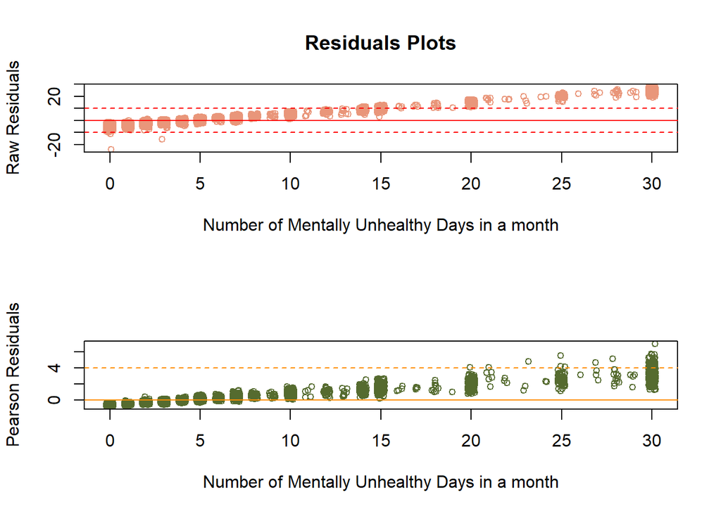

```r
par(mfrow=c(2,1))
# plot raw residuals against menthlth
plot(x=jitter(TRAIN$menthlth), y=m7$residuals, col="darksalmon", cex=0.8,
     ylab="Raw Residuals", xlab="Number of Mentally Unhealthy Days in a month",
     main="Residuals Plots")
# add the reference line: h=0
abline(h=c(0,-10,10), col="red", lty=c(1,2,2))
# plot Pearson residuals against menthlth
plot(x=jitter(TRAIN$menthlth), y=resid(m7,type="pearson"), col="darkolivegreen", cex=0.8,
     ylab="Pearson Residuals", xlab="Number of Mentally Unhealthy Days in a month")
# add the ref line: h=0
abline(h=c(0,4), col="darkorange", lty=c(1,2))
```

The singular point at the bottom-left of the raw residuals plot catches our attention — a respondent who self-reports to be completely fine is predicted to be mentally compromised for over $20$ days in a month. By looking into his case, we learn that he is a lower-class smoker who misses the higher education, uses cellphone and internet, drinks a lot of alcohol, and bears unpaid medical bills, all explaining the curious prediction. Yet the sleeping time contributes exceptionally. Could anybody survive from averagely sleeping two hours per day for a month? Is this record an error? Or more importantly, given all these detrimental factors, is he hiding his mental problems in the interview?

However, the respondent also exercises astonishingly intensely (a hard laborer, perhaps) and maintains perfect BMI. Incorporating the fact that some people are just genetically resistant to psychological damages, we conclude that this case is possible, albeit improbable, and should not be abandoned.

```r
TRAIN[which(m7$residuals <= -20), ]
```

```
##      menthlth DISTRICT                                               X_race
## 9420        0  Midwest American Indian or Alaskan Native only, Non-Hispanic
##      GENDER              X_educag Class cellphone internet medcost      BMI
## 9420      M Graduated high school lower       Yes      Yes     Yes 18.46876
##      children sleptim1 smoke100 maxdrnks fruit1 vegetab1 exeroft1        DIET
## 9420        1        2      Yes       40    101      301      230 -0.06437627
```

## Cross Validation

To evaluate how well the final model fits the training data and generalizes to new data, we repeat the fitting $k=5$ times, each time treating a different subset as the validation data and merging the other subsets as the training data. By doing so, all observations are used for both training and validation, and each observation is used for validation exactly once. We then assess the model performance by the square root of the mean squared error, both for fitting and for predicting.

```r
# repeat training and validation k times
# each time using the ith subset as validation data
# record sqrt(MSE) in every run
error_fitted <- c()
error_pred <- c()
days_pred <- list()
model <- list()
for (i in 1:k)
{
  TRAIN <- DATA %>% slice(setdiff(1:nrow(DATA),ID[[i]]))
  TEST <- DATA[ID[[i]],]
  model[[i]] <- zeroinfl(menthlth ~ children + BMI + sleptim1 + maxdrnks + exeroft1 + BMI:maxdrnks
                                   | GENDER + Class + internet + medcost + smoke100 + BMI,
                         data = TRAIN, dist = "negbin", EM = TRUE)
  error_fitted[[i]] <- sum((model[[i]]$fitted.values-TRAIN$menthlth)^2)
  error_fitted[i] <- sqrt(error_fitted[[i]]/nrow(TRAIN))
  days_pred[[i]] <- predict(model[[i]], TEST)
  error_pred[i] <- sqrt(sum((days_pred[[i]]-TEST$menthlth)^2)/nrow(TRAIN))
}
print(data.frame(Error_fitted=error_fitted, Error_predicted=error_pred))
```

```
##   Error_fitted Error_predicted
## 1     6.971459        3.541815
## 2     6.972303        3.527972
## 3     6.967197        3.537414
## 4     6.991470        3.506762
## 5     7.051887        3.374458
```

In fact, as shown in the figure below, the model fails to capture either the fat tail or the excess of zeros in the observations.

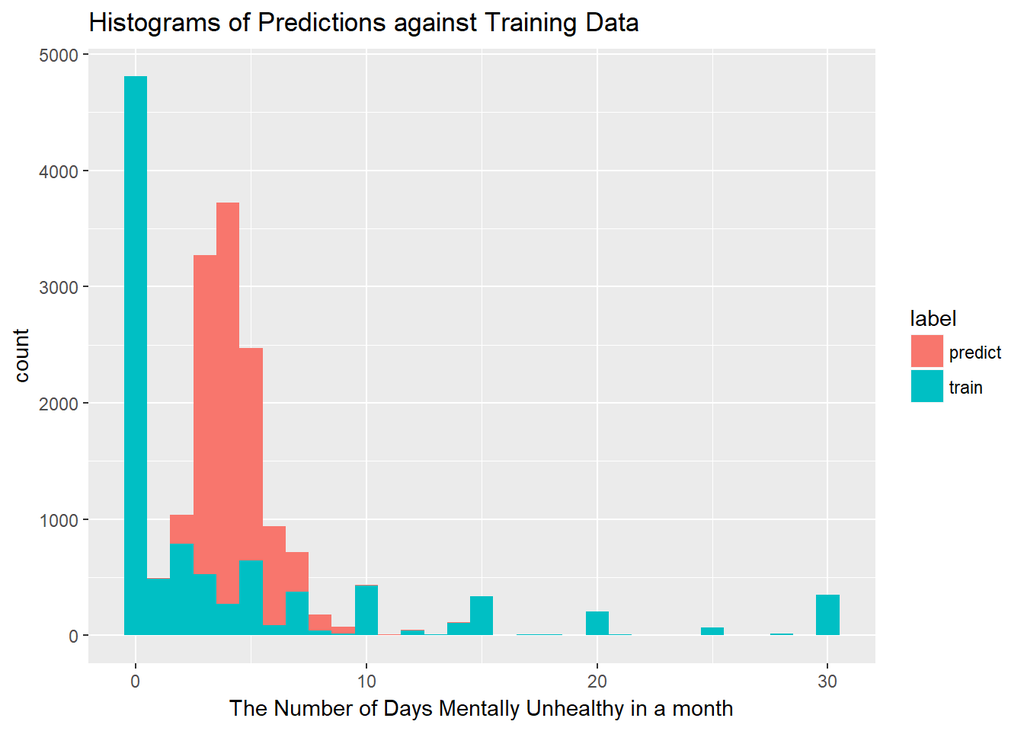

```r
df1 <- data.frame(DAYS=DATA$menthlth)
df2 <- data.frame(DAYS=predict(m7,DATA))
df1$label <- "train"
df2$label <- "predict"
ggplot(rbind(df1,df2), aes(DAYS,fill=label)) +
  geom_histogram(alpha=1, binwidth=1) +
  xlab("The Number of Days Mentally Unhealthy in a month") +
  ggtitle("Histograms of Predictions against Training Data")
```

```r
DATA <- DATA %>%
  mutate(DIAGNOSIS=factor(ifelse(menthlth<4,"fine","ill"))) %>%
  mutate(predict = predict(m7,DATA)) %>%
  mutate(PREDICT=factor(ifelse(predict<4, "negative","positive")))
# construct a contingency table
TAB <- table(DATA$PREDICT, DATA$DIAGNOSIS)
print(TAB)
```

```
##
##            fine  ill
##   negative 3770 1058
##   positive 2840 2005
```

```r
# compute sensitivity and specificity
cat("sensitivity:", round(TAB[2,2]/sum(TAB[,2]),digits=4),
    "\n specificity:", round(TAB[1,1]/sum(TAB[,1]),digits=4), "\n")
```

```
## sensitivity: 0.6546
##  specificity: 0.5703
```

Both the sensitivity (probability of true positiveness) and the specificity (probability of true negativeness) turn out to be acceptable. In other words, approximately $65\%$ of the respondents who are indeed suffering from mental illness would be correctly detected by our model and advised to see doctors, without harassing too many healthy people and burdening medical workers overwhelmingly.

## Interpretation

We would like to highlight that the **ZINB model** consists of two components, the **logistic regression** for the binary process and the **negative binomial regression** for the count process. And each component involves a different set of explanatory variables — say, $X$ and $Z$ — respectively.

### Logistic Regression

In the binary process, the logit of $\pi_j=P(W_j=1)$ is linearly modelled by

$$\log (\frac{\pi_j}{1 - \pi_j}) = \mathbf{X}_{(j)} \cdot \vec{\beta} + \epsilon_j$$
$$\hat{\pi} = \frac{\exp(\mathbf{X} \hat{\beta})}{1 + \exp(\mathbf{X} \hat{\beta})}$$

Therefore, the **intercept** $\beta_0 \approx -2.7205$ can be interpreted as that when BMI equals to $0$ (which is practically impossible) and all factors take the reference level, the probability of an American resident who is aged $18$ to $24$ being exposed to intrinsic or extrinsic triggering circumstances (i.e. $W=1$) is $\pi_0 = \exp{(\beta_0)}/(1 + \exp{(\beta_0)}) \approx 0.0618$.

### Negative Binomial Regression

In the count process, the expected days of feeling mentally unhealthy is logarithmatically linked to the linear combination of $\mathbf{Z}_{(j)}$.[^6]

$$\log (\mathbf{E}[Y_j|W_j=1]) = \mathbf{Z}_{(j)} \cdot \vec{\gamma} + \delta_j$$

$\hat{\gamma}$ has to be interpreted in terms of conditional expectation $E[Y|W=1]$. Given that an American resident aged $18$ to $24$ is exposed to triggering circumstances (i.e. $W=1$), the **intercept** $\gamma_0 \approx 1.9812 \approx \log (7.25)$ expresses the log of the expected number of unhealthy days elicited in a month when other variables all take zeros (again, some cases are practically impossible).

Conditional on $W=1$, the number of mentally disturbed days in a month is expected to be multiplied by $\exp (\gamma_1) \approx 1.0702$, on average, for one additional child that the young American has, holding other variables constant. The interpretation of the **slopes** is further complicated by the presence of **interaction**. Speciically, provided that $W=1$, we expect an additional unit of BMI to multiply the number of unhealthy days by $\exp (\gamma_2 + \gamma_6 \cdot \Delta) \approx \exp (0.0141 - 0.0017 \cdot \Delta)$, with $\Delta$ being the change in the number of glasses of alcohol that the young American drinks per day at maximum, averagely speaking and everything else held constant. We may also interpret the coefficients pertaining to the max number of drinks in a similar manner.

## Conclusion

A few interesting findings present themselves in the results. For example, under triggering circumstances, an increase in either BMI or the maximum number of drinks per day is expected to boost the occurrence of symptoms when affecting alone; but such rise inclines to be less steep if they work interactively. Can alcohol relieve the anxiety of becoming fat somehow? Is using diverse ways to handle bad mood, eating high-calorie food and getting drunk, healthier than using either one exclusively? Moreover, dropping predictors itself could be revealing. It is widely presumed that the pressure of caring for kids dominantly falls upon mothers, yet the lack of interaction between genders and the number of children tends not to support this prevalent view.

[^1]: https://www.nimh.nih.gov/health/statistics/major-depression.shtml
[^2]: https://www.ajmc.com/journals/supplement/2007/2007-11-vol13-n4suppl/nov07-2638ps092-s097?p=2
[^3]: https://www.bcmj.org/articles/early-detection-depression-young-and-elderly-people
[^4]: https://gss.norc.org/
[^5]: https://www.nimh.nih.gov/health/education-awareness/index.shtml
[^6]: https://ncss-wpengine.netdna-ssl.com/wp-content/themes/ncss/pdf/Procedures/NCSS/Negative_Binomial_Regression.pdf
[^7]: https://github.com/PawinData/GLM